```python
import pandas as pd
import seaborn as sns
import plotly.express as px
import plotly.graph_objects as go
import matplotlib.pyplot as plt
```

```python
import plotly.io as pio
pio.renderers.default = "plotly_mimetype+notebook"
```

# Matplotlib

For this excercise, we have written the following code to load the stock dataset built into plotly express.

```python
stocks = px.data.stocks()
stocks.head()
```

|  | date | GOOG | AAPL | AMZN | FB | NFLX | MSFT |
| --- | --- | --- | --- | --- | --- | --- | --- |
| 0 | 2018-01-01 | 1.000000 | 1.000000 | 1.000000 | 1.000000 | 1.000000 | 1.000000 |
| 1 | 2018-01-08 | 1.018172 | 1.011943 | 1.061881 | 0.959968 | 1.053526 | 1.015988 |
| 2 | 2018-01-15 | 1.032008 | 1.019771 | 1.053240 | 0.970243 | 1.049860 | 1.020524 |
| 3 | 2018-01-22 | 1.066783 | 0.980057 | 1.140676 | 1.016858 | 1.307681 | 1.066561 |
| 4 | 2018-01-29 | 1.008773 | 0.917143 | 1.163374 | 1.018357 | 1.273537 | 1.040708 |

## Question 1:

Select a stock and create a suitable plot for it. Make sure the plot is readable with relevant information, such as date, values.

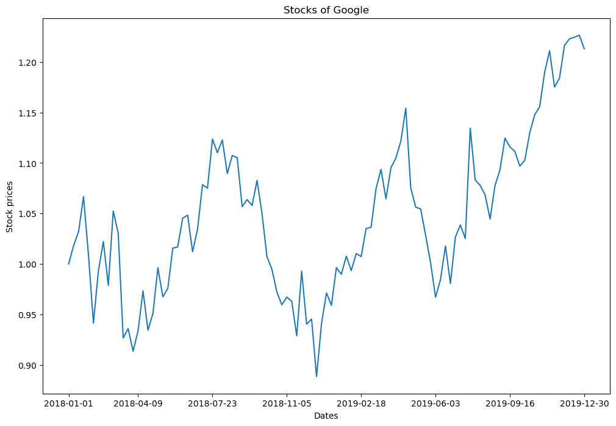

```python
# YOUR CODE HERE


fig, goog = plt.subplots(figsize=(12,8))
goog.plot(stocks.date,stocks.GOOG)
goog.set_title('Stocks of Google')
goog.set_xlabel('Dates')
goog.set_ylabel('Stock prices')
goog.set_xticks([0,14,29,44,59,74,89,104])
plt.xticks(rotation=0)
plt.show()
```

```python
stocks.count()
```

```
date    105
GOOG    105
AAPL    105
AMZN    105
FB      105
NFLX    105
MSFT    105
dtype: int64
```

## Question 2:

You've already plot data from one stock. It is possible to plot multiples of them to support comparison.  
To highlight different lines, customise line styles, markers, colors and include a legend to the plot.

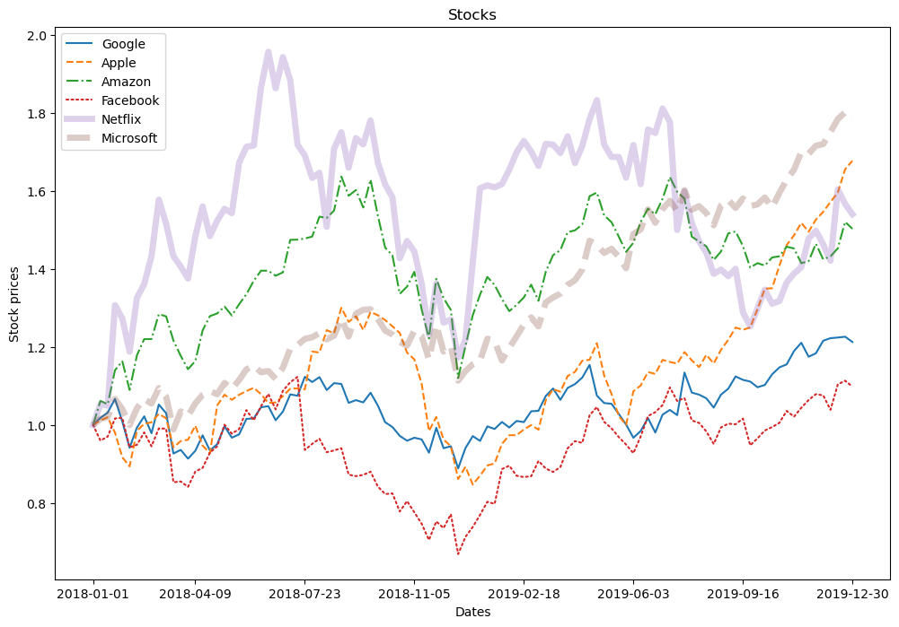

```python
fig, goog = plt.subplots(figsize=(12,8))
goog.plot(stocks.date,stocks.GOOG, label = "Google", linestyle='-')
goog.plot(stocks.date,stocks.AAPL, label = "Apple", linestyle='--')
goog.plot(stocks.date,stocks.AMZN, label = "Amazon", linestyle='-.')
goog.plot(stocks.date,stocks.FB, label = "Facebook", linestyle=':',dash_capstyle='round')
goog.plot(stocks.date,stocks.NFLX, label = "Netflix", linewidth=5, alpha=0.3)
goog.plot(stocks.date,stocks.MSFT, label = "Microsoft", linewidth=5, alpha=0.3, linestyle='--')
goog.set_title('Stocks')
goog.set_xlabel('Dates')
goog.set_ylabel('Stock prices')
goog.set_xticks([0,14,29,44,59,74,89,104])
goog.legend()
plt.xticks(rotation=0)
plt.show()
```

# Seaborn

First, load the [tips](https://github.com/mwaskom/seaborn-data/blob/master/tips.csv) dataset

```python
tips = sns.load_dataset('tips')
tips.head()
```

|  | total_bill | tip | sex | smoker | day | time | size |
| --- | --- | --- | --- | --- | --- | --- | --- |
| 0 | 16.99 | 1.01 | Female | No | Sun | Dinner | 2 |
| 1 | 10.34 | 1.66 | Male | No | Sun | Dinner | 3 |
| 2 | 21.01 | 3.50 | Male | No | Sun | Dinner | 3 |
| 3 | 23.68 | 3.31 | Male | No | Sun | Dinner | 2 |
| 4 | 24.59 | 3.61 | Female | No | Sun | Dinner | 4 |

## Question 3:

Let's explore this dataset. Pose a question and create a plot that support drawing answers for your question.

Some possible questions:

- Are there differences between male and female when it comes to giving tips?
- What attribute correlate the most with tip?

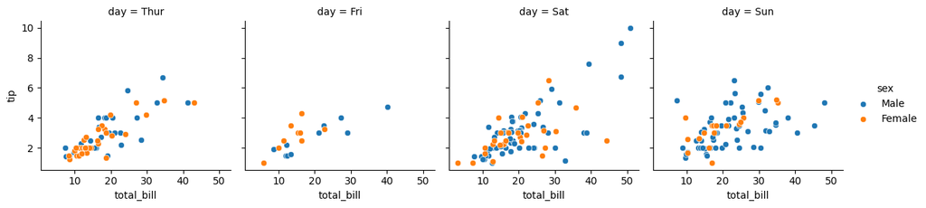

```python
g = sns.FacetGrid(tips, col='day', hue='sex')
g.map(sns.scatterplot, 'total_bill', 'tip')
g.add_legend()
plt.show()
```

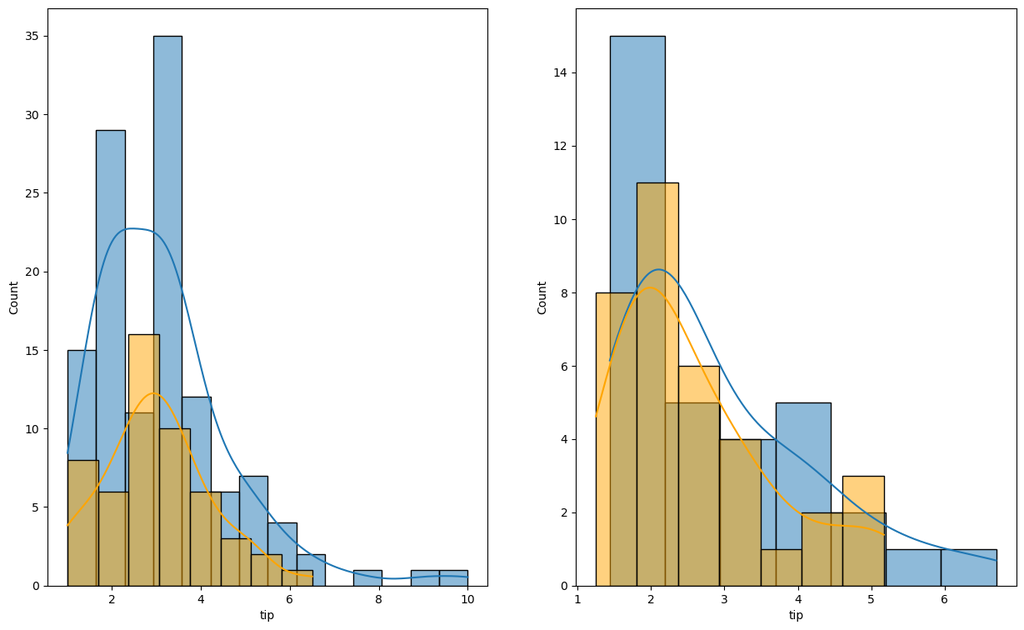

```python
maledinner =  tips[(tips['sex']=='Male') & (tips['time']=='Dinner')]
femaledinner = tips[(tips['sex']=='Female') & (tips['time']=='Dinner')]
malelunch = tips[(tips['sex']=='Male') & (tips['time']=='Lunch')]
femalelunch = tips[(tips['sex']=='Female') & (tips['time']=='Lunch')]


fig, ax = plt.subplots(ncols=2, figsize=(15,9))
sns.histplot(maledinner,x='tip',kde = True, ax=ax[0])
sns.histplot(femaledinner,x='tip',kde = True, ax=ax[0],color = 'orange' )
sns.histplot(malelunch,x='tip',kde = True, ax=ax[1])
sns.histplot(femalelunch,x='tip',kde = True, ax=ax[1], color = 'orange')
plt.show()
```

# Plotly Express

## Question 4:

Redo the above exercises (challenges 2 & 3) with plotly express. Create diagrams which you can interact with.

### The stocks dataset

*Hints*:

- Turn stocks dataframe into a structure that can be picked up easily with plotly express

```python
fig = px.line(stocks, x="date", y=["GOOG","AAPL","AMZN","FB","NFLX","MSFT"], markers=True)
fig.show()
```

[interactive chart not shown]

### The tips dataset

```python
df = px.data.tips()
fig1 = px.scatter(
   df[(df['smoker']=='No')&(df['time']=='Dinner')], x="total_bill", y="tip", color="sex",
   hover_data=df.columns, width=600, height=300, title = "no smoker at dinner")
fig2 = px.scatter(
   df[(df['smoker']=='No')&(df['time']=='Lunch')], x="total_bill", y="tip", color="sex",
   hover_data=df.columns, width=600, height=300, title = "no smoker at lunch")
fig3 = px.scatter(
   df[(df['smoker']=='Yes')&(df['time']=='Dinner')], x="total_bill", y="tip", color="sex",
   hover_data=df.columns, width=600, height=300, title = "smoker at dinner")
fig4 = px.scatter(
   df[(df['smoker']=='Yes')&(df['time']=='Lunch')], x="total_bill", y="tip", color="sex",
   hover_data=df.columns, width=600, height=300, title = "smoker at lunch")
fig1.show()
fig2.show()
fig3.show()
fig4.show()
```

[interactive chart not shown]

## Question 5:

*Hints:*

- Extract the 2007 year data from the dataframe. You have to process the data accordingly
- use [plotly bar](https://plotly.com/python-api-reference/generated/plotly.express.bar)
- Add different colors for different continents
- Sort the order of the continent for the visualisation. Use [axis layout setting](https://plotly.com/python/reference/layout/xaxis/)
- Add text to each bar that represents the population

```python
#load data
df = px.data.gapminder()
df.head()
```

|  | country | continent | year | lifeExp | pop | gdpPercap | iso_alpha | iso_num |
| --- | --- | --- | --- | --- | --- | --- | --- | --- |
| 0 | Afghanistan | Asia | 1952 | 28.801 | 8425333 | 779.445314 | AFG | 4 |
| 1 | Afghanistan | Asia | 1957 | 30.332 | 9240934 | 820.853030 | AFG | 4 |
| 2 | Afghanistan | Asia | 1962 | 31.997 | 10267083 | 853.100710 | AFG | 4 |
| 3 | Afghanistan | Asia | 1967 | 34.020 | 11537966 | 836.197138 | AFG | 4 |
| 4 | Afghanistan | Asia | 1972 | 36.088 | 13079460 | 739.981106 | AFG | 4 |

```python
# YOUR CODE HERE
fig = px.histogram(df[df['year'] == 2007],x='pop',y='continent',color = 'continent',barmode = 'group',text_auto = True)
fig.update_traces(textfont_size=12, textangle=0, textposition="outside")
fig.update_layout(yaxis_categoryorder = 'total ascending')
fig.update_layout(showlegend=False)
```

[interactive chart not shown]

[output not shown]